# American Psycho

Shamalan

10/11/2020

install.packages(“rmarkdown”)

```r
knitr::opts_chunk$set(echo = TRUE)
```

We have chosen to analyze the movie American Psycho released in the year 2000. American Psycho is a classic psychological horror film starring Christian Bale as Patrick Bateman.

Our treatment of the dataset involved several stages. They were the arranging, exploration and the interpretation of the data.

When it came to the arranging of the data set, we first scrutinized the “American Psycho” JSON file that we downloaded. We then converted the file to a csv file in order to make it much easier for us to read the dataset. Once in its csv format, we decided that we would utilize the variables “edges_source”, “edges_target” and “edges_weight”. The remaining variables were discarded.

We then decided to adjust the arrangement of the dataset by arranging it into a matrix in which every node that is present in the network has a row and column. The intersection between a specific node’s row and column would indicate the weight of the edges. This adjacency matrix would make it easier for us to read and interpret the data. ###

## R Markdown

```r
#Load the igraph library
library(igraph)
#Read the file
my_movie <- read.csv(file.choose(), header=TRUE, row.names=1)
my_matrix <- as.matrix(my_movie)
```

```r
#Arranging the data to a matrix
my_network2 <- graph.adjacency(my_matrix, mode="undirected", diag=FALSE)
my_network2
```

```
## IGRAPH 54efbfc UN-- 26 79 --
## + attr: name (v/c)
## + edges from 54efbfc (vertex names):
##  [1] WOMAN   --COPCAR       WOMAN   --BATEMAN      OWEN    --PRICE
##  [4] OWEN    --VAN.PATTEN   OWEN    --CARRUTHERS   OWEN    --BATEMAN
##  [7] OWEN    --BATEMAN      OWEN    --BATEMAN      OWEN    --WAITER
## [10] COPCAR  --BATEMAN      COURTNEY--PRICE        COURTNEY--EVELYN
## [13] COURTNEY--CARRUTHERS   COURTNEY--BATEMAN      COURTNEY--BATEMAN
## [16] COURTNEY--BATEMAN      PRICE   --CARNES       PRICE   --GUY.IN.STALL
## [19] PRICE   --VAN.PATTEN   PRICE   --VAN.PATTEN   PRICE   --LIBBY
## [22] PRICE   --CARON        PRICE   --KIMBALL      PRICE   --DAISY
## + ... omitted several edges
```

```r
#Network plot
w = simplify(my_network2)
E(w)$weight = sapply(E(w),
function(e) {length(all_shortest_paths(my_network2, from=ends(w, e)[1], to=ends(w, e)[2])$res) } )
```

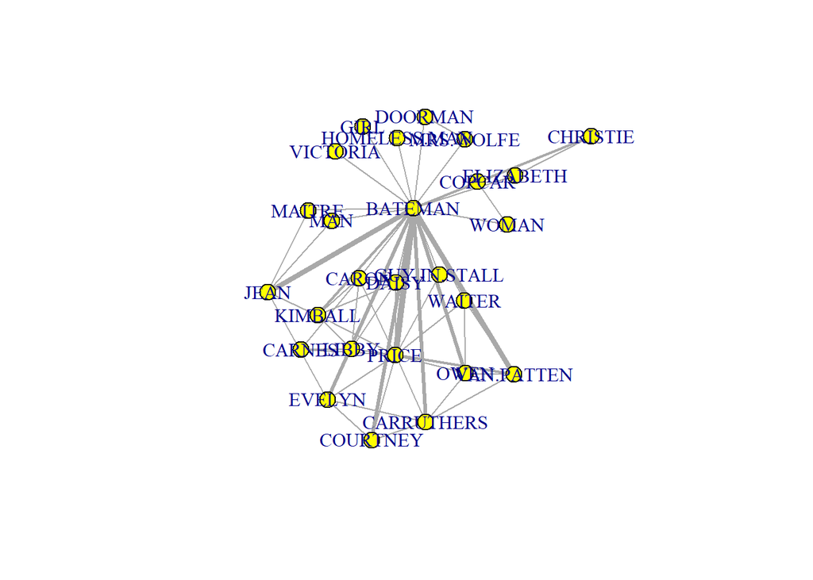

```r
#Weighted plot without multiple single connections
plot(w, vertex.size = 10, vertex.color = "yellow",
     edge.arrow.size = 0.15, edge.width=E(w)$weight,
     layout = layout.kamada.kawai)
```

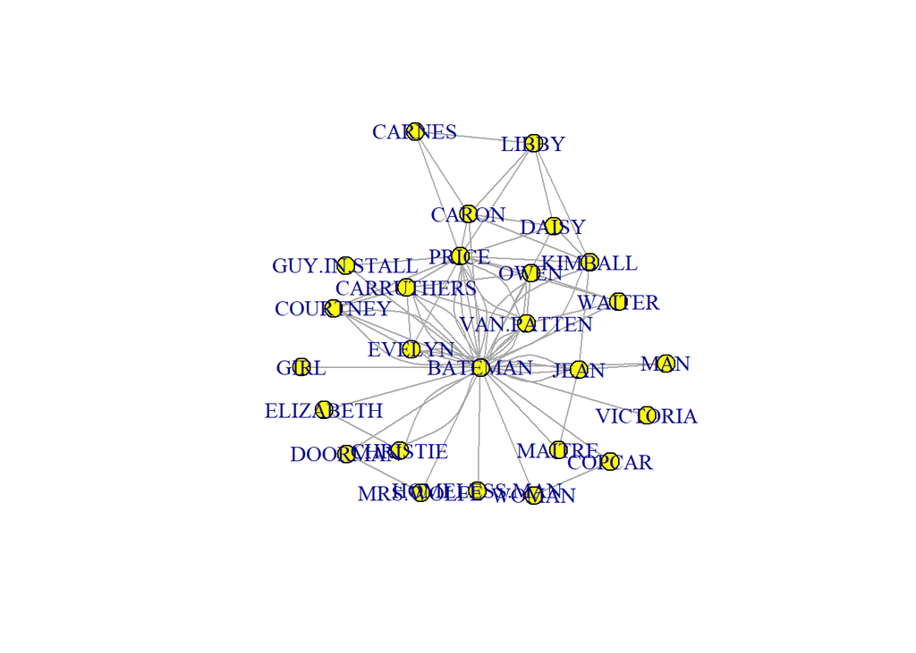

```r
#Weighted plot with multiple single connections
plot(my_network2, vertex.size = 10, vertex.color = "yellow",
     edge.arrow.size = 0.15,
     layout = layout.kamada.kawai)
```

```r
#Number of edges
gsize(my_network2)
```

```
## [1] 79
```

```r
#Number of Nodes
gorder(my_network2)
```

```
## [1] 26
```

```r
#CLIQUES
#Number of cliques
cliques(my_network2)
```

```
## [[1]]
## + 1/26 vertex, named, from 54efbfc:
## [1] BATEMAN
##
## [[2]]
## + 1/26 vertex, named, from 54efbfc:
## [1] LIBBY
##
## [[3]]
## + 1/26 vertex, named, from 54efbfc:
## [1] PRICE
##
## [[4]]
## + 2/26 vertices, named, from 54efbfc:
## [1] PRICE LIBBY
##
## [[5]]
## + 2/26 vertices, named, from 54efbfc:
## [1] PRICE   BATEMAN
##
## [[6]]
## + 1/26 vertex, named, from 54efbfc:
## [1] JEAN
##
## [[7]]
## + 2/26 vertices, named, from 54efbfc:
## [1] JEAN    BATEMAN
##
## [[8]]
## + 1/26 vertex, named, from 54efbfc:
## [1] ELIZABETH
##
## [[9]]
## + 2/26 vertices, named, from 54efbfc:
## [1] ELIZABETH BATEMAN
##
## [[10]]
## + 1/26 vertex, named, from 54efbfc:
## [1] MRS.WOLFE
##
```

[output cut: 604 more lines]

```
## [[162]]
## + 3/26 vertices, named, from 54efbfc:
## [1] OWEN       CARRUTHERS BATEMAN
##
## [[163]]
## + 2/26 vertices, named, from 54efbfc:
## [1] OWEN  PRICE
##
## [[164]]
## + 3/26 vertices, named, from 54efbfc:
## [1] OWEN    PRICE   BATEMAN
##
## [[165]]
## + 2/26 vertices, named, from 54efbfc:
## [1] OWEN    BATEMAN
```

```r
#Largest set of cliques
clique_num(my_network2)
```

```
## [1] 5
```

```r
#Number of cliques with 6 nodes
count_max_cliques(my_network2)
```

```
## [1] 17
```

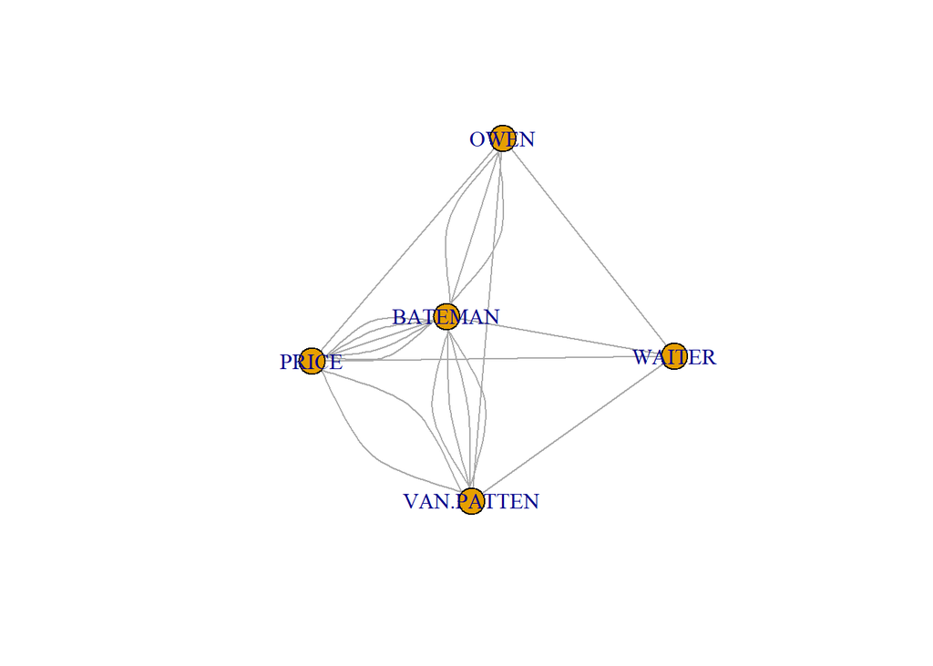

```r
#plot of largest cliques
a <- largest.cliques(my_network2)
clique1 <- a[[1]]
g2 <- induced.subgraph(graph=my_network2, vids=clique1)
plot(g2)
```

#The node that we would be analysing is Timothy Price (Price).

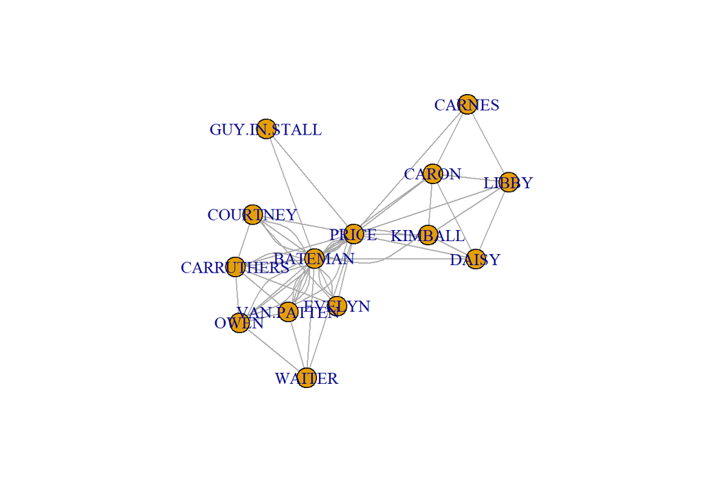

```r
#Node Analysis (Price)
p_node <- induced_subgraph(my_network2, ego(my_network2, 1, "PRICE")[[1]]) #neighbouring nodes of Price
plot(p_node)
```

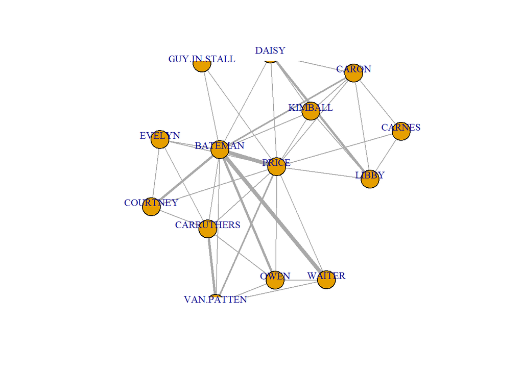

```r
#Weighted Plot for Node "Price"
p_node_2 = simplify(p_node)
E(p_node_2)$weight = sapply(E(g2), function(e){length(all_shortest_paths(p_node, from=ends(p_node_2, e)[1], to=ends(p_node_2, e)[2])$res)})
plot(p_node_2,
     vertix.size=15,
     vertex.label.dist=0.5,
     vertex.label.cex=0.8,
     vertex.label.degree=-pi/2,
     edge.width=E(p_node_2)$weight,
     layout=layout_with_kk,
     margin=-0.2)
```

#Based on the generated output, it is seen that Price has a degree of 18 which includes himself.

```r
#number of edges for Price
gsize(p_node)
```

```
## [1] 56
```

```r
#1. degree centrality = 14
degree(p_node)
```

```
##         OWEN     COURTNEY        PRICE       CARNES GUY.IN.STALL   VAN.PATTEN
##            7            6           18            3            2            9
##        LIBBY        CARON      KIMBALL        DAISY       EVELYN   CARRUTHERS
##            5            6            6            5            6            8
##      BATEMAN       WAITER
##           27            4
```

```r
#2. edges from price to Bateman = 18
edge_connectivity(p_node, source="BATEMAN", target="PRICE", checks=TRUE)
```

```
## [1] 17
```

```r
#3. betweenness centrality
betweenness(my_network2)
```

```
##        WOMAN         OWEN       COPCAR     COURTNEY        PRICE       CARNES
##    0.0000000    0.1666667    0.0000000    0.0000000   41.0433261    0.0000000
##          MAN GUY.IN.STALL   VAN.PATTEN         GIRL      DOORMAN     CHRISTIE
##    0.0000000    0.0000000    0.1666667    0.0000000    0.0000000    0.0000000
## HOMELESS.MAN    MRS.WOLFE        LIBBY        CARON         JEAN       MAITRE
##    0.0000000    0.0000000    0.7023810    4.1563492    1.9916667    0.0000000
##    ELIZABETH     VICTORIA      KIMBALL        DAISY       EVELYN   CARRUTHERS
##    0.0000000    0.0000000    4.3748196    1.3111111    0.2350150    0.3151515
##      BATEMAN       WAITER
##  235.5368465    0.0000000
```

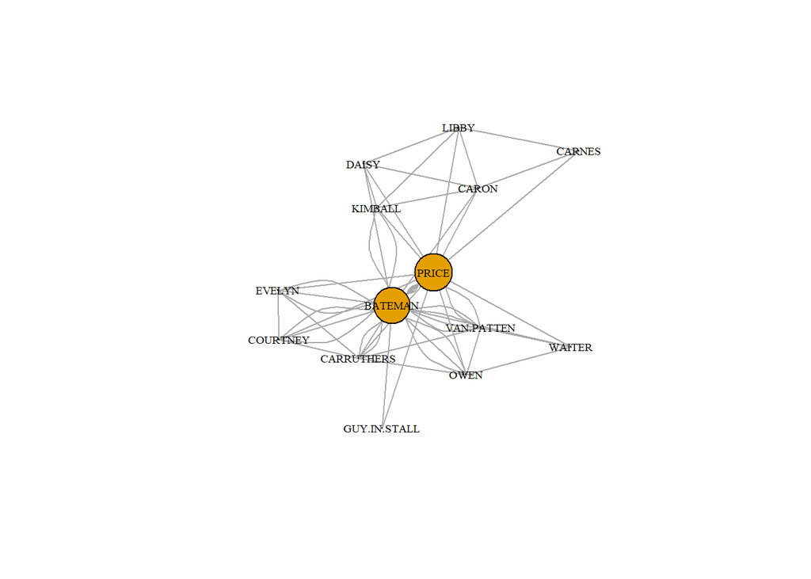

```r
V(p_node)$betweenness <- betweenness(p_node, directed=F)
plot(p_node,
     vertex.label.cex = .6,
     vertex.label.color="black",
     vertex.size = V(p_node)$betweenness)
```

#With closeness centrality, what we are measuring is the average closeness(distance) between a node to the others. In this case for Price, we saw a value of 0.027. This is explained by the average distance between Price and other nodes(characters) is 0.027. We can say that Price has a good wide connection with other characters as he has a high closeness value which is one place smaller than the protagonist Bateman.

```r
#4. closeness centrality
closeness(my_network2)
```

```
##        WOMAN         OWEN       COPCAR     COURTNEY        PRICE       CARNES
##   0.02000000   0.02222222   0.02000000   0.02173913   0.02702703   0.01694915
##          MAN GUY.IN.STALL   VAN.PATTEN         GIRL      DOORMAN     CHRISTIE
##   0.02000000   0.02083333   0.02222222   0.01960784   0.02000000   0.02000000
## HOMELESS.MAN    MRS.WOLFE        LIBBY        CARON         JEAN       MAITRE
##   0.01960784   0.02000000   0.01785714   0.02272727   0.02173913   0.02000000
##    ELIZABETH     VICTORIA      KIMBALL        DAISY       EVELYN   CARRUTHERS
##   0.02000000   0.01960784   0.02272727   0.02222222   0.02222222   0.02272727
##      BATEMAN       WAITER
##   0.03703704   0.02173913
```

#Degree centrality only takes into account into of the number of edges in each node, leaving out ego’s alter. With eigenvector centrality, it takes into account ego’s alter and we will be able to figure out which characters has powerful influence in the movie. Price has an eigenvector centrality value of 0.64 which is again the second highest losing to Bateman at 1.00. This shows that Price is still a powerful character in the given movie.

```r
#5. eigenvector centrality
evcent(my_network2)$vector
```

```
##        WOMAN         OWEN       COPCAR     COURTNEY        PRICE       CARNES
##   0.08200063   0.35539423   0.08200063   0.33269891   0.64059256   0.06886287
##          MAN GUY.IN.STALL   VAN.PATTEN         GIRL      DOORMAN     CHRISTIE
##   0.10350493   0.12433415   0.47096939   0.07578612   0.08200063   0.15822455
## HOMELESS.MAN    MRS.WOLFE        LIBBY        CARON         JEAN       MAITRE
##   0.07578612   0.08200063   0.09880384   0.16925104   0.36575049   0.10350493
##    ELIZABETH     VICTORIA      KIMBALL        DAISY       EVELYN   CARRUTHERS
##   0.08777735   0.07578612   0.26061315   0.16439985   0.35846501   0.39091392
##      BATEMAN       WAITER
##   1.00000000   0.18696104
```

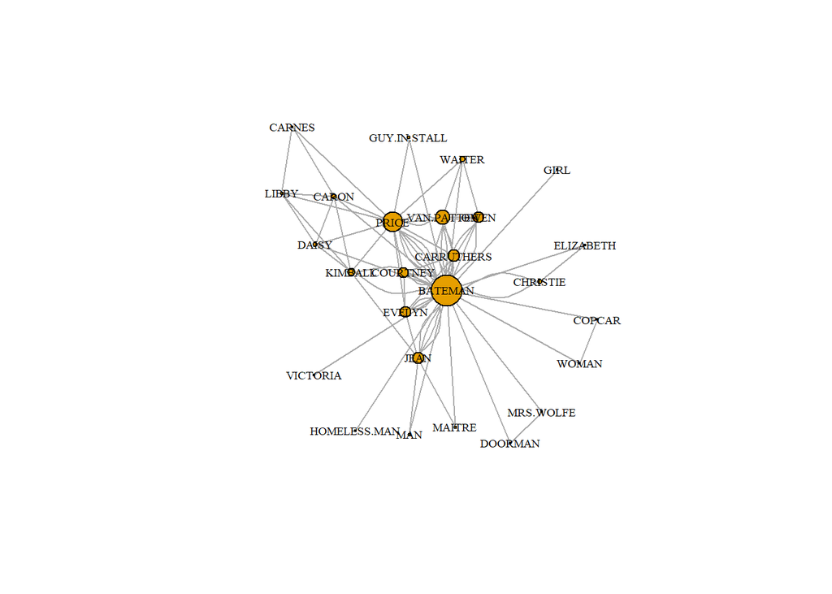

```r
V(my_network2)$eigenvector <- evcent(my_network2)$vector
plot(my_network2,
     vertex.label.cex = .6,
     vertex.label.color = "black",
     vertex.size = V(my_network2)$eigenvector/max(V(my_network2)$eigenvector) * 20)
```

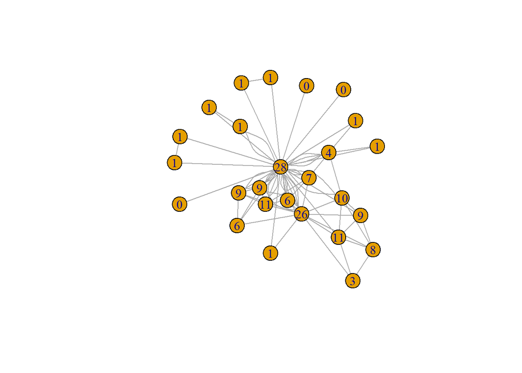

```r
#6. triangle value
atri <- count_triangles(my_network2)
plot(my_network2, vertex.label=atri)
```

#Eccentricity value for Price is 2. This means that the node(character) is in proximity to Price in which the furthest node away from Price is 2 vertices away. It is not considered far as the highest value we can see from the output is 3. The could be interpreted as Price do not have the widest connection to all the characters out there.

```r
#7. eccentricity
eccentricity(my_network2)
```

```
##        WOMAN         OWEN       COPCAR     COURTNEY        PRICE       CARNES
##            3            2            3            2            2            3
##          MAN GUY.IN.STALL   VAN.PATTEN         GIRL      DOORMAN     CHRISTIE
##            3            2            2            3            3            3
## HOMELESS.MAN    MRS.WOLFE        LIBBY        CARON         JEAN       MAITRE
##            3            3            3            2            3            3
##    ELIZABETH     VICTORIA      KIMBALL        DAISY       EVELYN   CARRUTHERS
##            3            3            2            2            2            2
##      BATEMAN       WAITER
##            2            2
```

#Price also has a Pagerank value of 0.098 which is one level lower as compared to Bateman’s 0.25. This is interpreted as the “ranking” of characters to identify which character has greater influential impact and we can say that Price is ranked second.

```r
#8. pagerank
page_rank(my_network2)
```

```
## $vector
##        WOMAN         OWEN       COPCAR     COURTNEY        PRICE       CARNES
##   0.01878507   0.04044164   0.01878507   0.03527688   0.09918253   0.02121705
##          MAN GUY.IN.STALL   VAN.PATTEN         GIRL      DOORMAN     CHRISTIE
##   0.01606847   0.01548503   0.05031614   0.01080141   0.01878507   0.02322031
## HOMELESS.MAN    MRS.WOLFE        LIBBY        CARON         JEAN       MAITRE
##   0.01080141   0.01878507   0.03217111   0.03737727   0.04957226   0.01606847
##    ELIZABETH     VICTORIA      KIMBALL        DAISY       EVELYN   CARRUTHERS
##   0.01738050   0.01080141   0.04187527   0.03133409   0.04061025   0.04514105
##      BATEMAN       WAITER
##   0.25456928   0.02514788
##
## $value
## [1] 1
##
## $options
## NULL
```